# Cottonwood Creek

Sadie Gill, Mark Tompkins

July 1, 2019

## Floodplain Modeling Details

**Data Source:** [USFWS / FEMA 1D HEC-RAS hydraulic model](https://s3-us-west-2.amazonaws.com/cvpiahabitat-r-package/cvpia-sit-model-inputs/CVPIA+Annual+Progress+Report+Fiscal+Year+2017.pdf)

### Fall Run

A 22.4 mile portion of the entire mapped rearing extent of 22.4 miles was modeled using USFWS / FEMA 1D HEC-RAS hydraulic model. Of the entire mapped rearing extent, 22.4 miles were classified as low gradient and 0 miles were classified as high gradient based on a geomorphic analysis. Floodplain area per unit length was determined for the modeled extent and applied to determine areas for the non-modeled extent. A scaling factor of 0.1 was applied to the area per unit length for the high gradient extent. No scaling factor was applied to the low gradient extent.

### Spring Run

A 22.4 mile portion of the entire mapped rearing extent of 119.5 miles was modeled using USFWS / FEMA 1D HEC-RAS hydraulic model. Of the entire mapped rearing extent, 22.4 miles were classified as low gradient and 97.1 miles were classified as high gradient based on a geomorphic analysis. Floodplain area per unit length was determined for the modeled extent and applied to determine areas for the non-modeled extent. A scaling factor of 0.1 was applied to the area per unit length for the high gradient extent. No scaling factor was applied to the low gradient extent.

### Steelhead

A 22.4 mile portion of the entire mapped rearing extent of 142.3 miles was modeled using USFWS / FEMA 1D HEC-RAS hydraulic model. Of the entire mapped rearing extent, 22.4 miles were classified as low gradient and 119.9 miles were classified as high gradient based on a geomorphic analysis. Floodplain area per unit length was determined for the modeled extent and applied to determine areas for the non-modeled extent. A scaling factor of 0.1 was applied to the area per unit length for the high gradient extent. No scaling factor was applied to the low gradient extent.

## Floodplain Data

| flow_cfs | FR_floodplain_acres | SR_floodplain_acres | ST_floodplain_acres | watershed |
| --- | --- | --- | --- | --- |
| 40 | 0 | 0 | 0 | Cottonwood Creek |
| 400 | 0 | 0 | 0 | Cottonwood Creek |
| 760 | 0 | 0 | 0 | Cottonwood Creek |
| 1120 | 0 | 0 | 0 | Cottonwood Creek |
| 1480 | 0 | 0 | 0 | Cottonwood Creek |

## Floodplain Plot

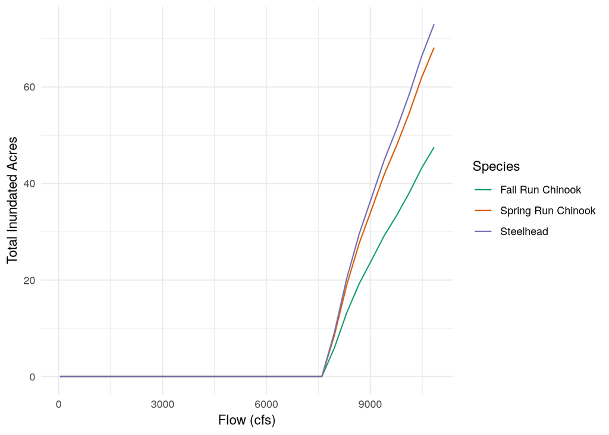